# Report1

## (1) Introduction

- map of tunisia
- star wars
- hannibal
- colesium
- lack of usage of alternative data in the developing world

## (2) Description of data

- Linkage data was collected from INS website
- INS website is very slow
- Planet didn’t provide large enough coverage eg. at the country level
- Many sources for satellite imagery

## (3) Analysis of data quality

Some of the variable names are unclear, probably due to shoddy translation (i.e. what is the diff between ‘Number of households having drinking water from the public source or source of water association’ and ‘Number of households having drinking water from the other public or private source’? - translation - stata

## (4) Main analysis (Exploratory Data Analysis)

Extensive data processing

### (4.a) A First Look at Tunisia

TODO: - supress the warning messages (add appropriate notation inside {r …}) - remove Ariana from original data

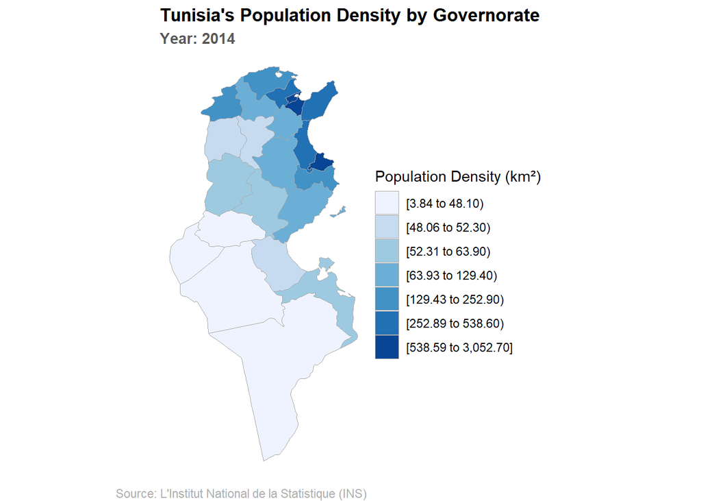

Comments: - coastal - point out tunis - Note: (1/24) Gov Ariana not included in the ChoroplethrAdmin 1 library

### (4.b) Population breakdown by Industry and Gender

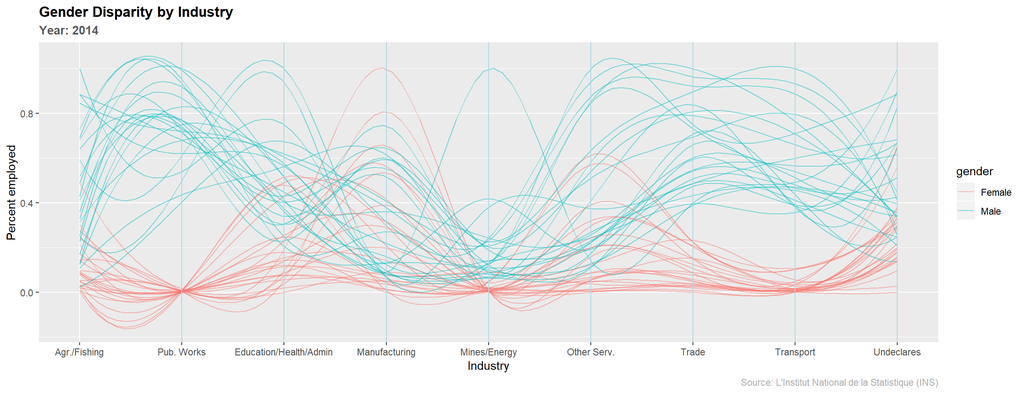

Comments: - interesting peak for mines/energy and manufactoring

### (4.c) Consumption by Governorates

TODO: - add after map bar plot or cleveland dot plot to show ranking of governorates by consumption

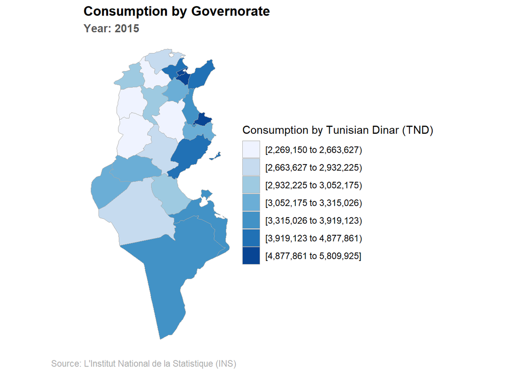

Comments: - definie consumption - can include excat categories that made up total - per capital - first comma from the right is delignating cents - show top 5 - focus on sfax

### (4.d) Luminosity trends across Tunisia

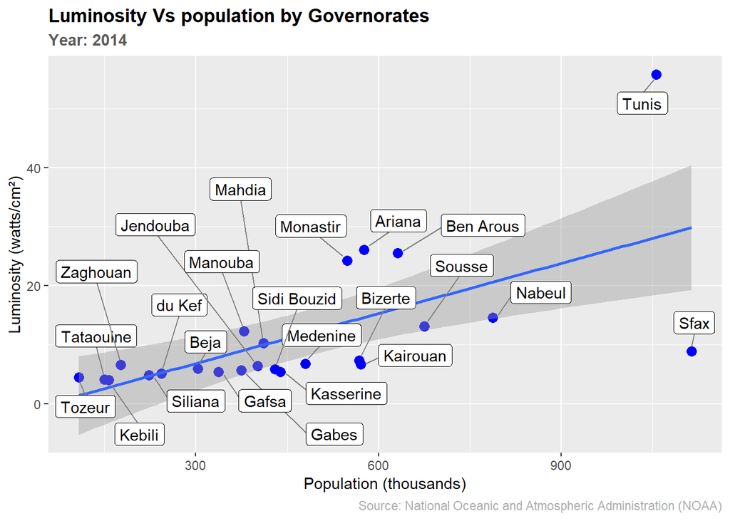

Comments: - sfax outlier - general comment: eg. as population goes up luminsity goes up - “transition comment”: Looking at consumption in descending order

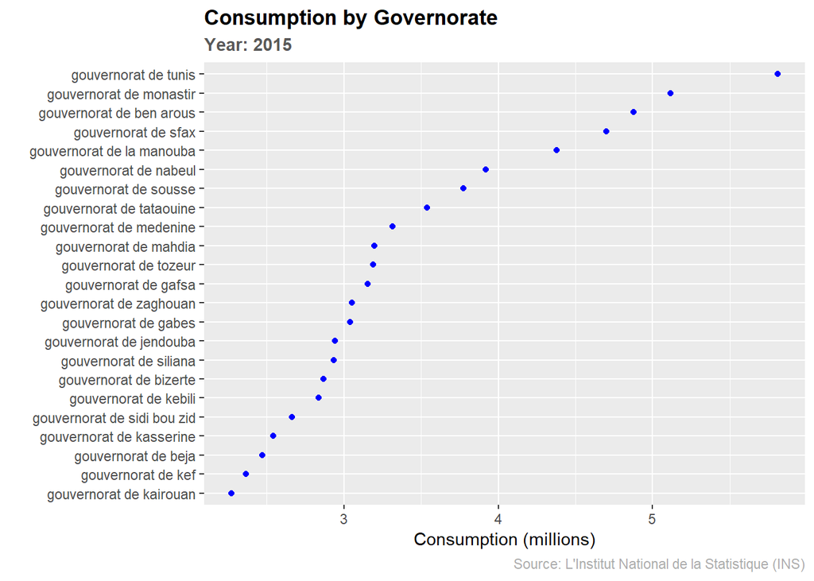

Comments: - note sfax is part of top 5 but is a clear outlier in the lowess plot

### (4.e) A closer at outliers: Sfax

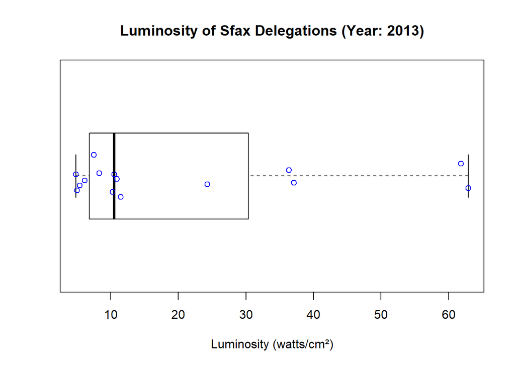

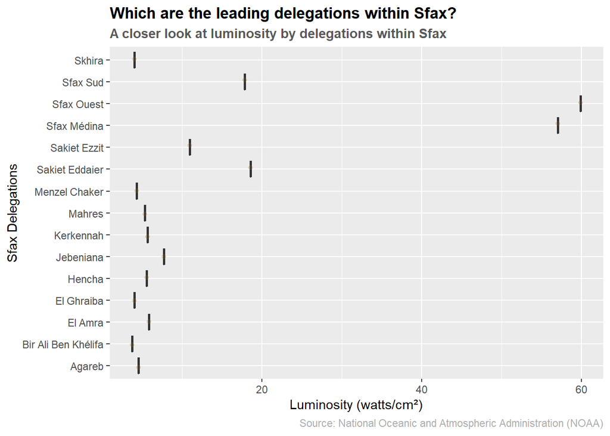

What might explain such variation in luminosity? - a little more

### (4.f) Exploring potential covariates of luminosity

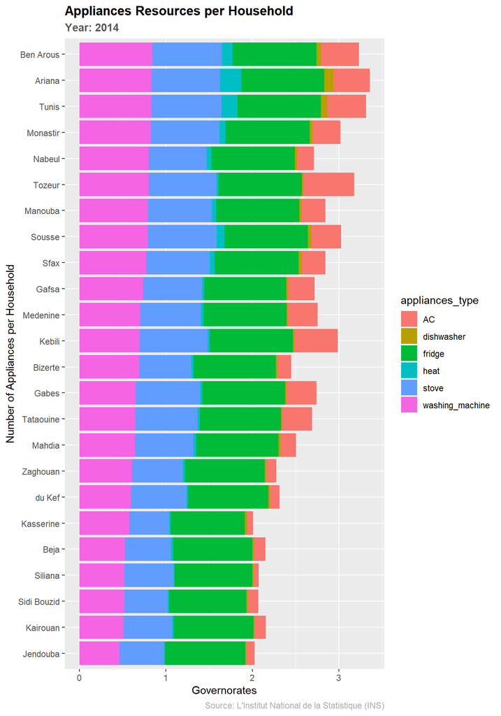

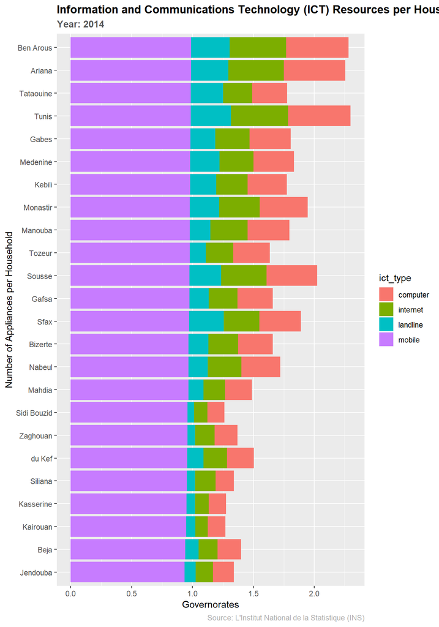

# Leisure Resources

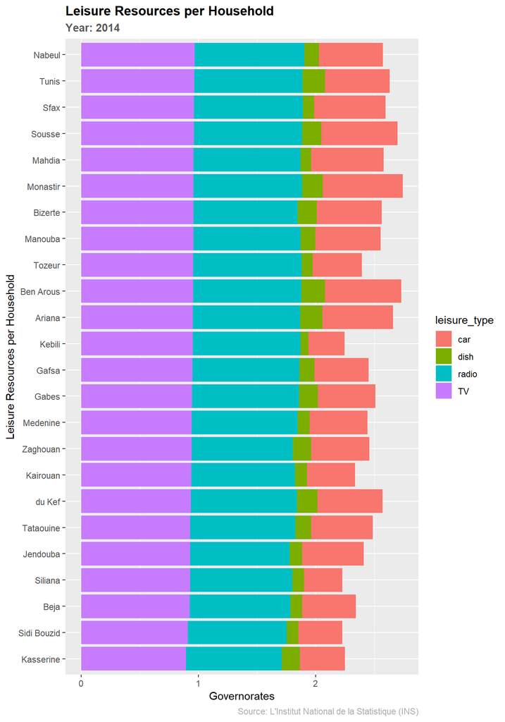

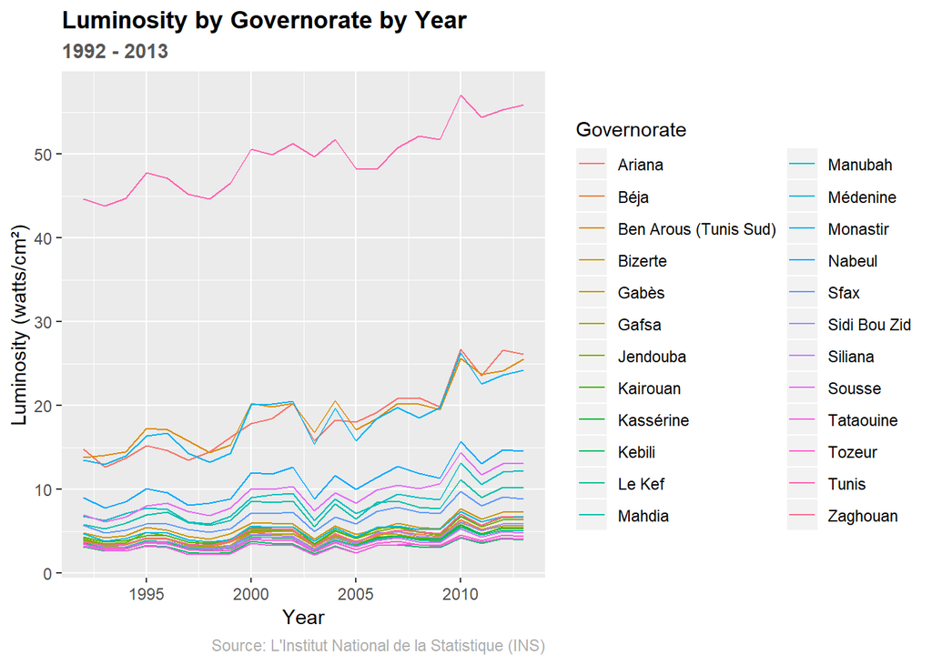

Comments: - tunis obviously - and the middle ones - why near one another

For a frame of reference, see appendix with graph of high, medium and low luminositites

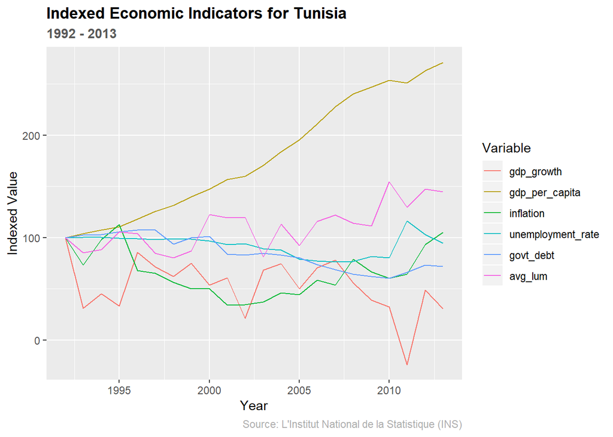

Comments: - maybe push this to conclusion - maybe rename variables - more from Namson

```
##                         year count        sum gdp_growth      gdp_ppp
## year               1.0000000    NA  0.7329709 -0.4007986  0.989903076
## count                     NA     1         NA         NA           NA
## sum                0.7329709    NA  1.0000000 -0.3818728  0.751756723
## gdp_growth        -0.4007986    NA -0.3818728  1.0000000 -0.397664279
## gdp_ppp            0.9899031    NA  0.7517567 -0.3976643  1.000000000
## gdp_per_capita     0.9895421    NA  0.7433196 -0.3841289  0.999346158
## inflation         -0.1098110    NA  0.1436795 -0.1029147 -0.008166219
## unemployment_rate -0.3512514    NA -0.1185138 -0.3242774 -0.355587641
## govt_debt         -0.9141032    NA -0.6580060  0.3674089 -0.927997907
## avg_lum            0.7329709    NA  1.0000000 -0.3818728  0.751756723
##                   gdp_per_capita    inflation unemployment_rate  govt_debt
## year                  0.98954214 -0.109810976        -0.3512514 -0.9141032
## count                         NA           NA                NA         NA
## sum                   0.74331962  0.143679478        -0.1185138 -0.6580060
## gdp_growth           -0.38412887 -0.102914738        -0.3242774  0.3674089
## gdp_ppp               0.99934616 -0.008166219        -0.3555876 -0.9279979
## gdp_per_capita        1.00000000 -0.027981867        -0.3835113 -0.9366557
## inflation            -0.02798187  1.000000000         0.3097474  0.1539523
## unemployment_rate    -0.38351131  0.309747374         1.0000000  0.5039443
## govt_debt            -0.93665573  0.153952295         0.5039443  1.0000000
## avg_lum               0.74331962  0.143679478        -0.1185138 -0.6580060
##                      avg_lum
## year               0.7329709
## count                     NA
## sum                1.0000000
## gdp_growth        -0.3818728
## gdp_ppp            0.7517567
## gdp_per_capita     0.7433196
## inflation          0.1436795
## unemployment_rate -0.1185138
## govt_debt         -0.6580060
## avg_lum            1.0000000
```

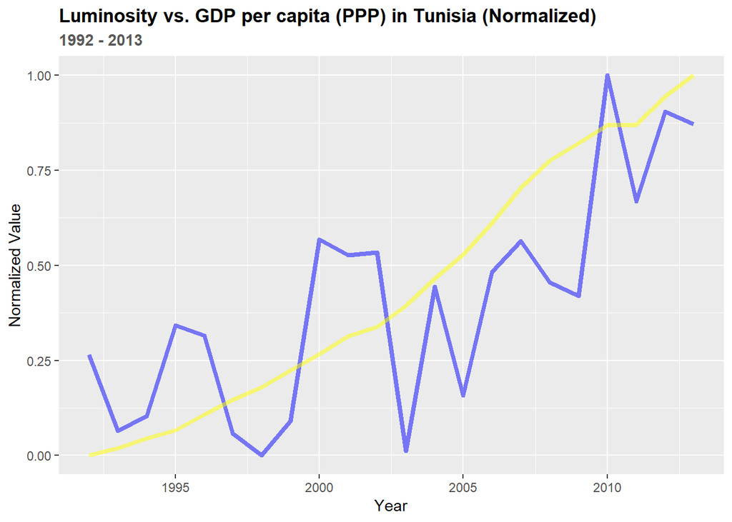

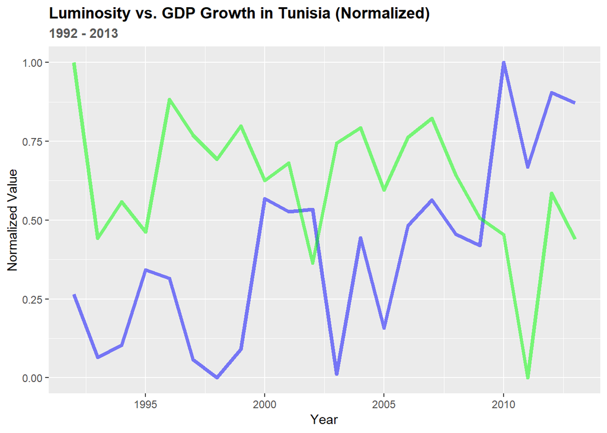

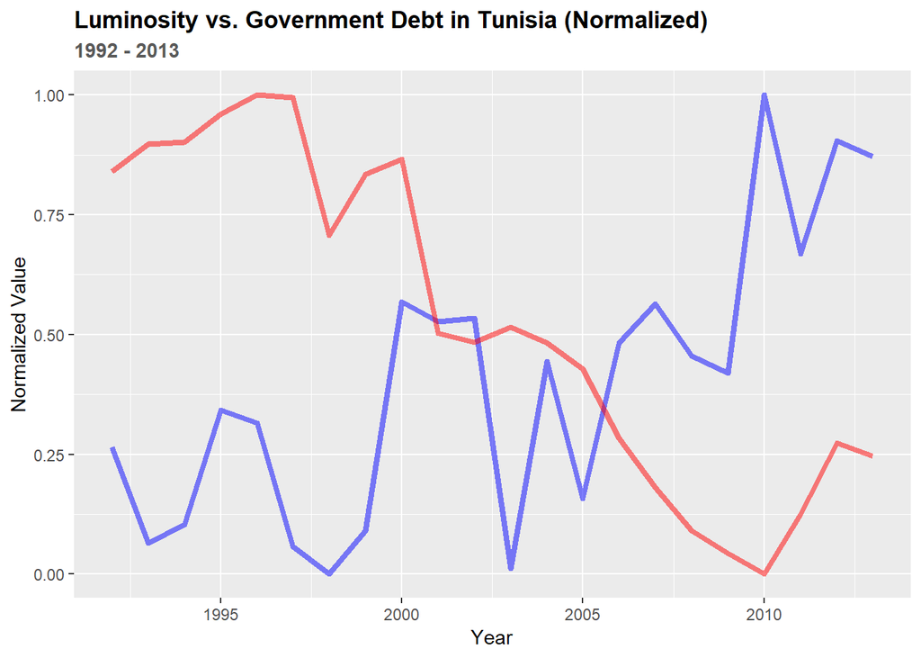

## (7) Conclusion

- Interested in looking at 2011 (year of the jasmine revolution) sicne the GDP went drastically down (Maybe less economic activity? Look into lumnisity?)
- Time series of luminosity per governorate
- !! Make a comment about coastal governorates
- https://academic.oup.com/eurpub/article/24/suppl_1/6/560448 - info on Choucha refugee crisis and 20% increase in Medeneine population
- Challenge: choroplethr naming for governorates is very specific and does not support french accent”. Two regions are missing.
- Bin side - looked into curtomizing it but very time consuming

## Appendix

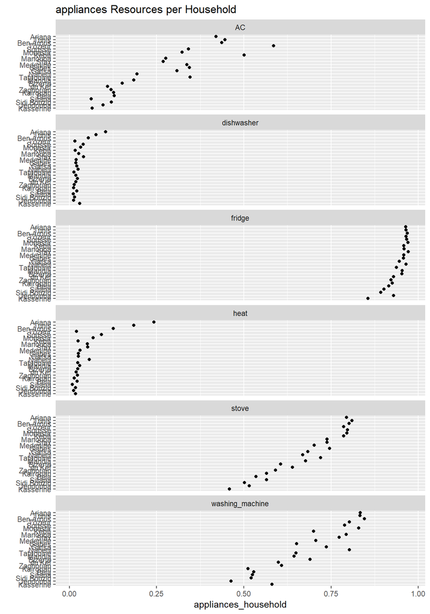

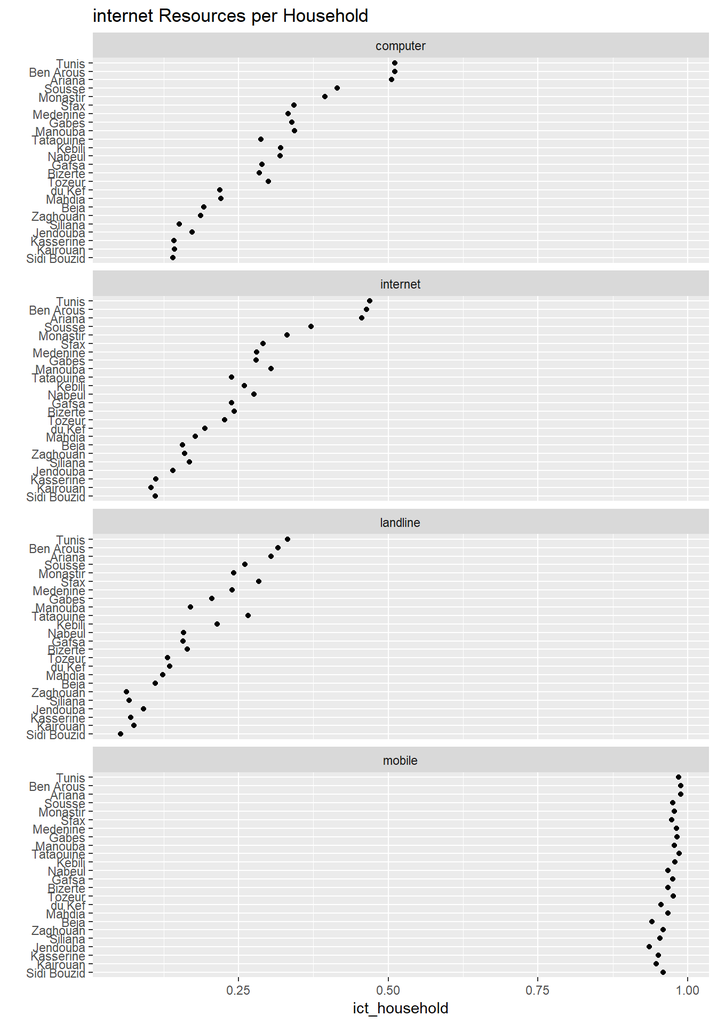

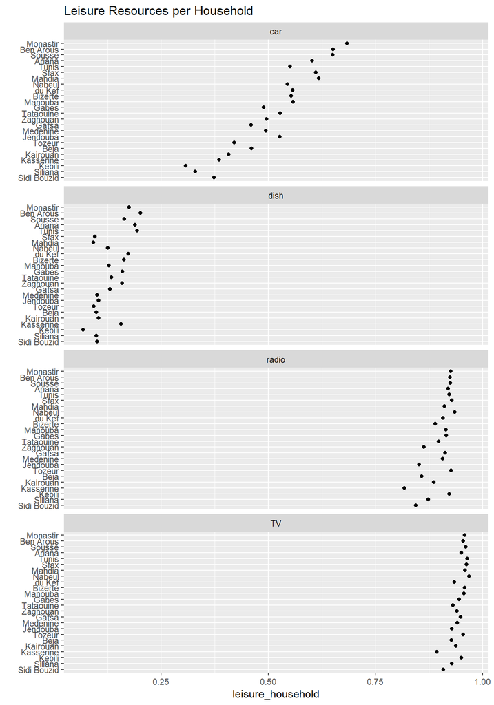

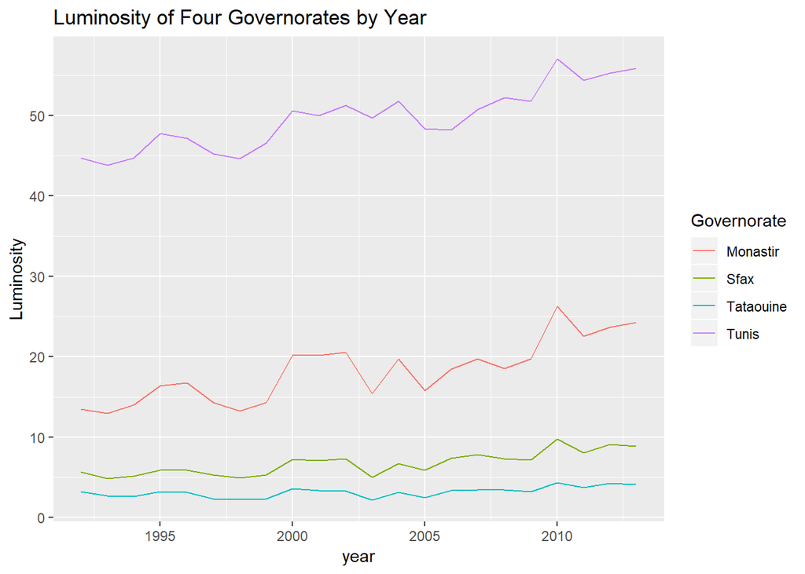